# The Metropolis Engine: Mechanics & Calibration

Deconstructing the Random Walk, the Metropolis Acceptance Ratio, and the Step-Size Dilemma

```r
knitr::opts_chunk$set(echo = TRUE, message = FALSE, warning = FALSE)

library(dplyr)
library(ggplot2)
library(scales)

source("R/metropolis_sampler.R")
source("R/plots.R")

# Target: Correlated bivariate normal
target_toy <- function(theta) {
  mu <- c(0, 0)
  sigma <- matrix(c(1.0, 0.75, 0.75, 1.0), nrow = 2)
  -0.5 * t(theta - mu) %*% solve(sigma) %*% (theta - mu)
}

# Run 3 chains with varying step sizes to demonstrate tuning
chain_timid <- run_metropolis(target_toy, initial_theta = c(0, 0), iterations = 2000, proposal_sd = 0.03, seed = 101)
chain_wild  <- run_metropolis(target_toy, initial_theta = c(0, 0), iterations = 2000, proposal_sd = 3.20, seed = 101)
chain_tuned <- run_metropolis(target_toy, initial_theta = c(0, 0), iterations = 2000, proposal_sd = 1.20, seed = 101)
```

#### The Four Steps of Metropolis-Hastings

Rather than solving high-dimensional integrals analytically, the Metropolis-Hastings algorithm generates samples from an unnormalized target density via four iterative steps:
1. **Propose a Candidate Move:** Given the current state $\theta^{(t)}$, sample candidate coordinates $\theta^*$ from a symmetric proposal distribution:
$$\theta^* \sim \mathcal{N}\left(\theta^{(t)}, \sigma_{\epsilon}^2 \mathbf{I}\right)$$
2. **Evaluate the Metropolis Acceptance Ratio ($\alpha$):** Compare target density at the candidate position to the current state:
$$\alpha = \min\left(1, \frac{p(\theta^*)}{p(\theta^{(t)})}\right)$$
In practice, this is evaluated in log-space to prevent numerical floating-point underflow:
$$\log \alpha = \min\left(0, \log p(\theta^*) - \log p(\theta^{(t)})\right)$$
3. **The Acceptance Decision:** Draw a uniform scalar $u \sim \text{Uniform}(0, 1)$ . If $\log u < \log \alpha$, the candidate is accepted:
$$\theta^{(t+1)} = \theta^*$$
Otherwise, the candidate is rejected, and the chain remains in place:
$$\theta^{(t+1)} = \theta^{(t)}$$

**Note**

While occasionally accepting lower-density moves enables traversal across non-convex surfaces, standard Random-Walk Metropolis remains vulnerable to getting trapped between separated modes on complex, multimodal target surfaces.

4. **Iterate:** Repeating this transition rule generates an empirical chain whose visited states converge asymptotically to the target posterior distribution $p(\theta \mid \mathcal{D})$.

### The Complete Engine in R

Below is the complete sampling engine implemented from first principles in base R:

```r
library(tibble)
library(dplyr)

run_metropolis <- function(target_log_posterior,
                           initial_theta,
                           iterations = 5000,
                           proposal_sd = 0.05,
                           seed = NULL) {
  if (!is.null(seed)) set.seed(seed)

  d <- length(initial_theta)
  theta_current <- initial_theta
  log_p_current <- target_log_posterior(theta_current)

  draws_mat <- matrix(NA_real_, nrow = iterations, ncol = d)
  accepted  <- logical(iterations)
  log_probs <- numeric(iterations)

  for (t in 1:iterations) {
    if (is.matrix(proposal_sd)) {
      theta_candidate <- MASS::mvrnorm(1, mu = theta_current, Sigma = proposal_sd)
    } else {
      theta_candidate <- rnorm(d, mean = theta_current, sd = proposal_sd)
    }

    log_p_candidate <- target_log_posterior(theta_candidate)
    log_alpha <- log_p_candidate - log_p_current

    if (!is.na(log_alpha) && log(runif(1)) < log_alpha) {
      theta_current <- theta_candidate
      log_p_current <- log_p_candidate
      accepted[t]   <- TRUE
    } else {
      accepted[t]   <- FALSE
    }

    draws_mat[t, ] <- theta_current
    log_probs[t]   <- log_p_current
  }

  param_names <- if (!is.null(names(initial_theta))) {
    names(initial_theta)
  } else {
    paste0("theta_", seq_len(d))
  }

  draws_df <- as_tibble(draws_mat, .name_repair = "minimal")
  colnames(draws_df) <- param_names
  draws_df <- draws_df %>% mutate(iteration = seq_len(iterations))

  diagnostics_df <- tibble(
    iteration = seq_len(iterations),
    accepted = accepted,
    log_posterior = log_probs
  )

  list(
    draws = draws_df,
    acceptance_rate = mean(accepted),
    diagnostics = diagnostics_df,
    dimensions = d,
    proposal_sd = proposal_sd
  )
}
```

### The Step-Size Dilemma: Tuning Proposal Variance

The primary operational lever in Random-Walk Metropolis is the proposal standard deviation ($\sigma_{\epsilon}$). Tuning this parameter governs the trade-off between spatial displacement per jump and proposal rejection frequency:

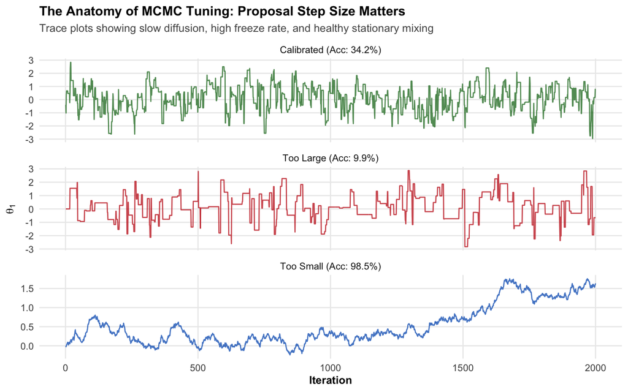

Figure 1: Trace plots illustrating the impact of proposal step size on chain mixing and acceptance

```r
#| fig-width: 10
#| fig-height: 10

plot_step_size_comparison(chain_timid, chain_wild, chain_tuned)
```

**Understanding the Trace Plots**

The trace panels illustrate the trajectory of parameter $\theta_1$ over 2,000 steps under three distinct proposal step sizes ($\sigma_\epsilon$), showing how proposal variance governs chain exploration:

1. **Too Timid ($\sigma_{\epsilon} = 0.03$ — Bottom Panel):** Almost every proposal is accepted (98.5% acceptance), but displacement per step is small. The chain wanders sluggishly through diffusion rather than stationary mixing, exhibiting strong positive autocorrelation and requiring extensive iterations to traverse the distribution.
2. **Too Aggressive ($\sigma_{\epsilon} = 3.20$ — Middle Panel):** Large proposal jumps land frequently in low-probability density tails, leading to a rejection rate exceeding 90% (9.9% acceptance). The trace exhibits horizontal flatlines where the state remains frozen across multiple consecutive iterations.
3. **Calibrated ($\sigma_{\epsilon} = 1.20$ — Top Panel):** Jump radius is balanced against target density gradients, achieving an empirical acceptance rate of approximately 34.2% (aligning with theoretical targets of 25% to 40% for low dimensions). The trajectory rapidly oscillates across the distribution center. However, while a calibrated acceptance rate is necessary, it does not alone guarantee rapid autocorrelation decay when applied to high-dimensional, correlated parameters.